# COVID_19_Analysis_w_recoveries

## COVID 19 Analysis with recoveries

The focus will be the US, but for reference information from Singapore, South Korea and Germany will be used as well.

```r
#Load John Hopkins University Data - From Local copy. Same information available in Github website
Confirmed = read.csv("C:/Users/figue/OneDrive/Documents/GitHub/COVID-19/csse_covid_19_data/csse_covid_19_time_series/time_series_covid19_confirmed_global.csv",stringsAsFactors = FALSE)
Deaths= read.csv("C:/Users/figue/OneDrive/Documents/GitHub/COVID-19/csse_covid_19_data/csse_covid_19_time_series/time_series_covid19_deaths_global.csv",stringsAsFactors = FALSE)
Recovered= read.csv("C:/Users/figue/OneDrive/Documents/GitHub/COVID-19/csse_covid_19_data/csse_covid_19_time_series/time_series_covid19_recovered_global.csv",stringsAsFactors = FALSE)

#I will obtain differences with diff function


#diff(as.numeric(Confirmed[1,c(5:dim(Confirmed)[2])]))
#initialize
Confirmed_daily = diff(as.numeric(Confirmed[1,c(5:dim(Confirmed)[2])]))
for(i in 2:dim(Confirmed)[1]){
  Confirmed_daily=rbind(Confirmed_daily,diff(as.numeric(Confirmed[i,c(5:dim(Confirmed)[2])])))
}
#assign column names

colnames(Confirmed_daily) = colnames(Confirmed[,(6:dim(Confirmed)[2])])
#column bind

Confirmed_daily = cbind(Confirmed[,c(1:4)],Confirmed_daily)

#do the same for Deaths and Recovered


#diff(as.numeric(Deaths[1,c(5:dim(Deaths)[2])]))
#initialize
Deaths_daily = diff(as.numeric(Deaths[1,c(5:dim(Deaths)[2])]))
for(i in 2:dim(Deaths)[1]){
  Deaths_daily=rbind(Deaths_daily,diff(as.numeric(Deaths[i,c(5:dim(Deaths)[2])])))
}
#assign column names

colnames(Deaths_daily) = colnames(Deaths[,(6:dim(Deaths)[2])])
#column bind

Deaths_daily = cbind(Deaths[,c(1:4)],Deaths_daily)

Recovered_daily = diff(as.numeric(Recovered[1,c(5:dim(Recovered)[2])]))
for(i in 2:dim(Recovered)[1]){
  Recovered_daily=rbind(Recovered_daily,diff(as.numeric(Recovered[i,c(5:dim(Recovered)[2])])))
}
#assign column names

colnames(Recovered_daily) = colnames(Recovered[,(6:dim(Recovered)[2])])
#column bind

Recovered_daily = cbind(Recovered[,c(1:4)],Recovered_daily)
```

## R Markdown

Modify previously defined function to accept Recovered data.

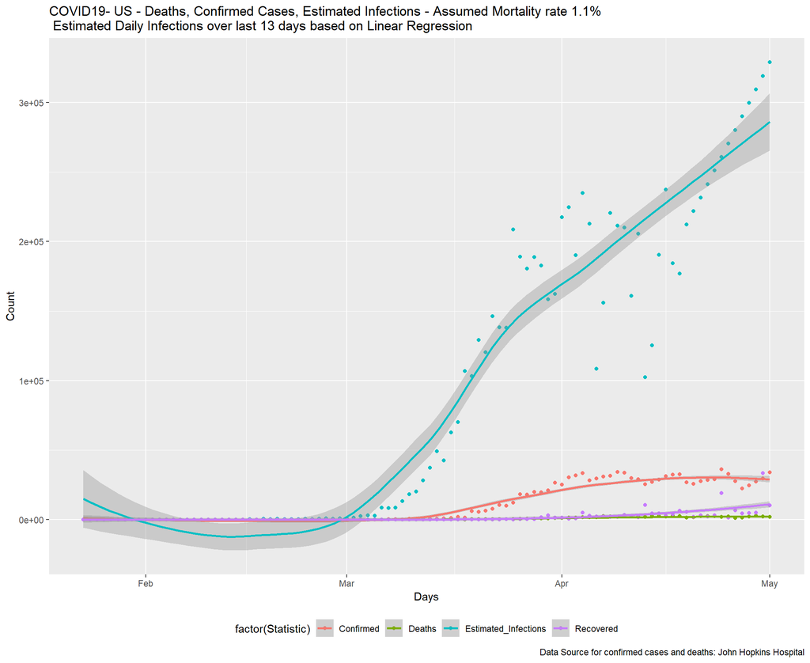

```r
#Returns a Dataframe to use in Ggplot that
library(ggplot2)
Estimated.Daily.Infections.Country <- function(Confirm.Daily, Death.Daily , Recovered.Daily, Country.Terr, State=NA, Lag=14 , Mortality=0.01){
  # Have to add checks in the future. Currently it works with Exact Matches
  library(reshape2)

  if (is.na(State)){
    Country.Confirmed = Confirm.Daily[Confirm.Daily$Country.Region == Country.Terr,]
    Country.Deaths = Death.Daily[Death.Daily$Country.Region == Country.Terr,]
    Country.Recovered = Recovered.Daily[Recovered.Daily$Country.Region == Country.Terr,]
  }else {
    Country.Confirmed = Confirm.Daily[Confirm.Daily$Country.Region == Country.Terr & Confirm.Daily$Province.State == State,]
    Country.Deaths = Death.Daily[Death.Daily$Country.Region == Country.Terr & Death.Daily$Province.State == State,]
    Country.Recovered = Recovered.Daily[Recovered.Daily$Country.Region == Country.Terr & Recovered.Daily$Province.State == State,]
  }

  #confirmed transform into long format
  Country.Confirmed$Statistic = "Confirmed"

  Country.Confirmed.Long = reshape(Country.Confirmed,varying = colnames(Country.Confirmed[,5:(dim(Country.Confirmed)[2]-1)]),v.names="Confirmed",idvar=c("Province.State","Country.Region","Lat","Long","Statistic"),direction="long")
  #Add corresponding date to Count
  Country.Confirmed.Long$Date_Name = colnames(Country.Confirmed[,5:(dim(Country.Confirmed)[2]-1)])

  #transform recovered to long
    Country.Recovered$Statistic = "Recovered"

  Country.Recovered.Long = reshape(Country.Recovered,varying = colnames(Country.Recovered[,5:(dim(Country.Recovered)[2]-1)]),v.names="Recovered",idvar=c("Province.State","Country.Region","Lat","Long","Statistic"),direction="long")
  #Add corresponding date to Count
  Country.Recovered.Long$Date_Name = colnames(Country.Recovered[,5:(dim(Country.Recovered)[2]-1)])

  #create Dataframe for Deaths. Transform into long format



  Country.Deaths$Statistic = "Deaths"
  Country.Deaths.Long = reshape(Country.Deaths,varying = colnames(Country.Deaths[,5:(dim(Country.Deaths)[2]-1)]),v.names="Deaths",idvar=c("Province.State","Country.Region","Lat","Long","Statistic"),direction="long")

  #Add corresponding date to Count
  Country.Deaths.Long$Date_Name = colnames(Country.Deaths[,5:(dim(Country.Deaths)[2]-1)])
  Country.Deaths.Long$Estimated_Infections = NA
  #Deaths is a 14 lag to infections. 1% Mortality rate. Have to start from row 15
  ##Maximum Lag will be 14
  if (Lag >15 ) Lag=14
  #Have to add limits to morality rate >0 and <=1
  Country.Deaths.Long[c(1:(dim(Country.Deaths.Long)[1]-Lag)),"Estimated_Infections"] = Country.Deaths.Long[c((Lag+1):dim(Country.Deaths.Long)[1]),"Deaths"]*(1/Mortality)

  #merge deaths and confirmed

  Country = merge(Country.Confirmed.Long,Country.Deaths.Long[,c("Date_Name","Deaths","Estimated_Infections")],by="Date_Name")
  #add Country recovered Country.Recovered.Long
  Country = merge(Country,Country.Recovered.Long[,c("Date_Name","Recovered")],by="Date_Name")
  Country = Country[order(Country$time),]

  #add dates in right format. Convert Date_Name

  Country$Date = as.Date(substr(Country$Date_Name,2,nchar(Country$Date_Name)),format ="%m.%d.%y")
  #change  for ggplot

  Country.Long = melt(Country[c("Date","Confirmed","Deaths","Estimated_Infections","Recovered")],id="Date")
  #update names
  colnames(Country.Long) = c("Date","Statistic","Count")
  #calculate linear regression with last 5 values of Estimated infections
  Est.Infect.reduced = Country.Long[Country.Long$Statistic=="Estimated_Infections",c("Date","Count")]
  #only 5 values prior to NA
  temp = min(which(is.na(Est.Infect.reduced$Count)))

  lm.infect = lm(Count ~ Date, data=Est.Infect.reduced[c((temp-5):(temp-1)),])
  #predict for missing dates and append to Es.Infect.reduced

  #predict based on 5 last records and add to NAs as probable number of  infections. Directly to

  #predict(lm.infect,newdata=data.frame(Date=Est.Infect.reduced[is.na(Est.Infect.reduced$Count),"Date"]))
  #Est.Infect.reduced[is.na(Est.Infect.reduced$Count),"Date"] = predict(lm.infect,newdata=data.frame(Date=Est.Infect.reduced[is.na(Est.Infect.reduced$Count),"Date"]))
  Country.Long[Country.Long$Statistic=="Estimated_Infections" & is.na(Country.Long$Count),"Count"] = predict(lm.infect,newdata=data.frame(Date=Est.Infect.reduced[is.na(Est.Infect.reduced$Count),"Date"]))

  return(Country.Long)

}

#Example with US- 1.1% Mortaliy rate and 13 day lag of Number of Death to Estimated Infections
Country.Long = Estimated.Daily.Infections.Country(Confirmed_daily,Deaths_daily,Recovered_daily,"US",NA,13,0.011)

ggplot(Country.Long, aes(x= Date, y= Count, group=Statistic )) +   geom_point(aes(color = factor(Statistic))) + geom_smooth(method = "loess", aes(color = factor(Statistic))) + theme(legend.position="bottom") + labs(title="COVID19- US - Deaths, Confirmed Cases, Estimated Infections - Assumed Mortality rate 1.1% \n Estimated Daily Infections over last 13 days based on Linear Regression", y="Count", x="Days", caption="Data Source for confirmed cases and deaths: John Hopkins Hospital")
```

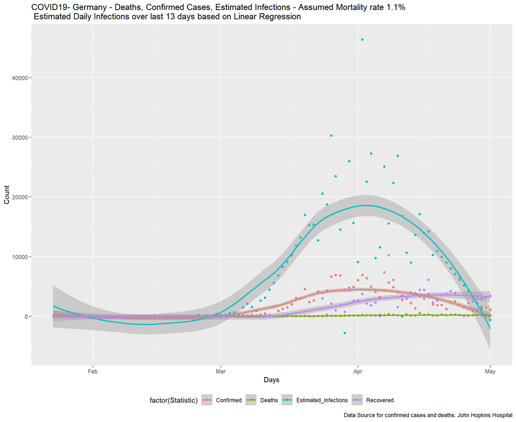

```r
#example with Germany

Country.Long = Estimated.Daily.Infections.Country(Confirmed_daily,Deaths_daily,Recovered_daily,"Germany",NA,13,0.011)

ggplot(Country.Long, aes(x= Date, y= Count, group=Statistic )) +   geom_point(aes(color = factor(Statistic))) + geom_smooth(method = "loess", aes(color = factor(Statistic))) + theme(legend.position="bottom") + labs(title="COVID19- Germany - Deaths, Confirmed Cases, Estimated Infections - Assumed Mortality rate 1.1% \n Estimated Daily Infections over last 13 days based on Linear Regression", y="Count", x="Days", caption="Data Source for confirmed cases and deaths: John Hopkins Hospital")
```

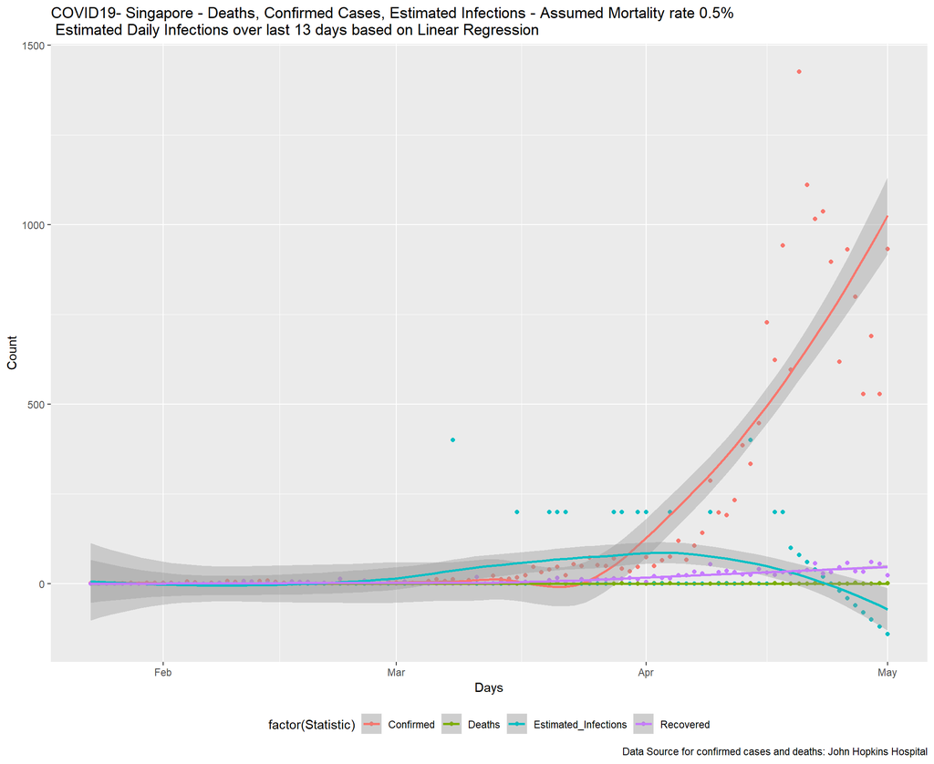

```r
#example with Singapore use mortality of 0.5% due to younger population being infected

Country.Long = Estimated.Daily.Infections.Country(Confirmed_daily,Deaths_daily,Recovered_daily,"Singapore",NA,13,0.005)

ggplot(Country.Long, aes(x= Date, y= Count, group=Statistic )) +   geom_point(aes(color = factor(Statistic))) + geom_smooth(method = "loess", aes(color = factor(Statistic))) + theme(legend.position="bottom") + labs(title="COVID19- Singapore - Deaths, Confirmed Cases, Estimated Infections - Assumed Mortality rate 0.5% \n Estimated Daily Infections over last 13 days based on Linear Regression", y="Count", x="Days", caption="Data Source for confirmed cases and deaths: John Hopkins Hospital")
```

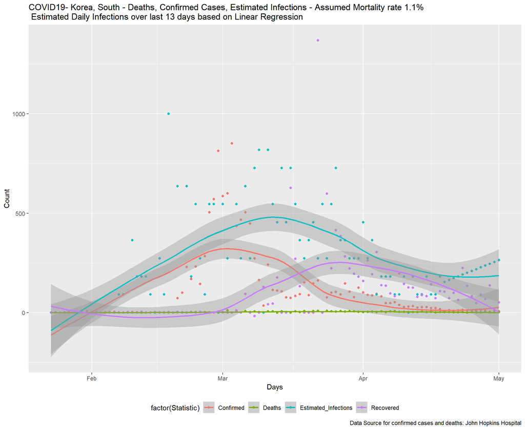

```r
#example with "Korea, South"

Country.Long = Estimated.Daily.Infections.Country(Confirmed_daily,Deaths_daily,Recovered_daily,"Korea, South",NA,13,0.011)

ggplot(Country.Long, aes(x= Date, y= Count, group=Statistic )) +   geom_point(aes(color = factor(Statistic))) + geom_smooth(method = "loess", aes(color = factor(Statistic))) + theme(legend.position="bottom") + labs(title="COVID19- Korea, South - Deaths, Confirmed Cases, Estimated Infections - Assumed Mortality rate 1.1% \n Estimated Daily Infections over last 13 days based on Linear Regression", y="Count", x="Days", caption="Data Source for confirmed cases and deaths: John Hopkins Hospital")
```

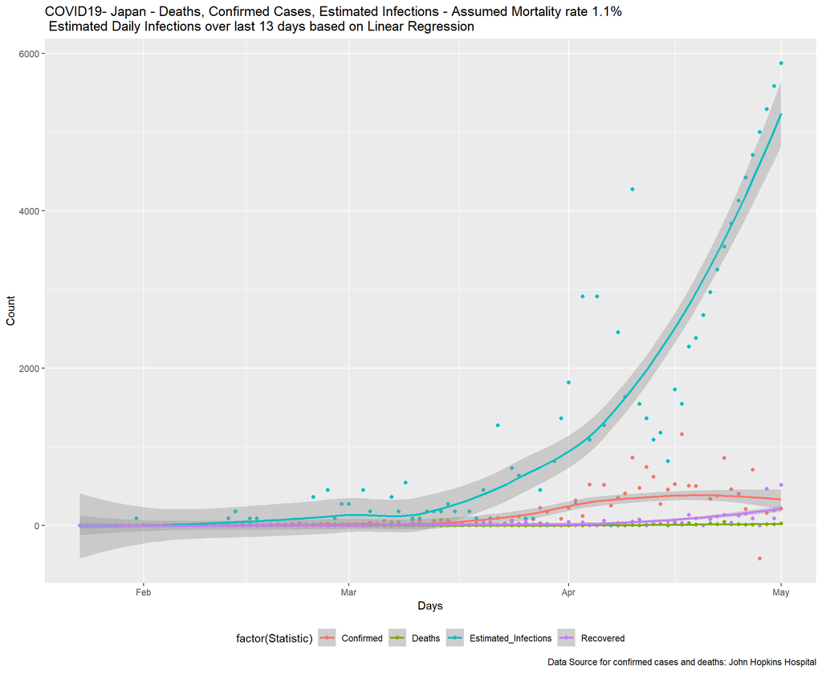

```r
#example with Japan

Country.Long = Estimated.Daily.Infections.Country(Confirmed_daily,Deaths_daily,Recovered_daily,"Japan",NA,13,0.011)

ggplot(Country.Long, aes(x= Date, y= Count, group=Statistic )) +   geom_point(aes(color = factor(Statistic))) + geom_smooth(method = "loess", aes(color = factor(Statistic))) + theme(legend.position="bottom") + labs(title="COVID19- Japan - Deaths, Confirmed Cases, Estimated Infections - Assumed Mortality rate 1.1% \n Estimated Daily Infections over last 13 days based on Linear Regression", y="Count", x="Days", caption="Data Source for confirmed cases and deaths: John Hopkins Hospital")
```

## Based on Previous Plots about Daily Rate of Infections

The following Chunk modified the function slightely to remove Recovered data frame. This will be used for information of States and Counties in the US

```r
Estimated.Daily.Infections.US <- function(Confirm.Daily, Death.Daily , Country.Terr, State=NA, Lag=14 , Mortality=0.01){
  # Have to add checks in the future. Currently it works with Exact Matches
  library(reshape2)

  if (is.na(State)){
    Country.Confirmed = Confirm.Daily[Confirm.Daily$Country.Region == Country.Terr,]
    Country.Deaths = Death.Daily[Death.Daily$Country.Region == Country.Terr,]
  }else {
    Country.Confirmed = Confirm.Daily[Confirm.Daily$Country.Region == Country.Terr & Confirm.Daily$Province.State == State,]
    Country.Deaths = Death.Daily[Death.Daily$Country.Region == Country.Terr & Death.Daily$Province.State == State,]
  }

  #confirmed transform into long format
  Country.Confirmed$Statistic = "Confirmed"

  Country.Confirmed.Long = reshape(Country.Confirmed,varying = colnames(Country.Confirmed[,5:(dim(Country.Confirmed)[2]-1)]),v.names="Confirmed",idvar=c("Province.State","Country.Region","Lat","Long","Statistic"),direction="long")
  #Add corresponding date to Count
  Country.Confirmed.Long$Date_Name = colnames(Country.Confirmed[,5:(dim(Country.Confirmed)[2]-1)])



  #create Dataframe for Deaths. Transform into long format



  Country.Deaths$Statistic = "Deaths"
  Country.Deaths.Long = reshape(Country.Deaths,varying = colnames(Country.Deaths[,5:(dim(Country.Deaths)[2]-1)]),v.names="Deaths",idvar=c("Province.State","Country.Region","Lat","Long","Statistic"),direction="long")

  #Add corresponding date to Count
  Country.Deaths.Long$Date_Name = colnames(Country.Deaths[,5:(dim(Country.Deaths)[2]-1)])
  Country.Deaths.Long$Estimated_Infections = NA
  #Deaths is a 14 lag to infections. 1% Mortality rate. Have to start from row 15
  ##Maximum Lag will be 14
  if (Lag >15 ) Lag=14
  #Have to add limits to morality rate >0 and <=1
  Country.Deaths.Long[c(1:(dim(Country.Deaths.Long)[1]-Lag)),"Estimated_Infections"] = Country.Deaths.Long[c((Lag+1):dim(Country.Deaths.Long)[1]),"Deaths"]*(1/Mortality)

  #merge deaths and confirmed

  Country = merge(Country.Confirmed.Long,Country.Deaths.Long[,c("Date_Name","Deaths","Estimated_Infections")],by="Date_Name")
  #add Country recovered Country.Recovered.Long

  Country = Country[order(Country$time),]

  #add dates in right format. Convert Date_Name

  Country$Date = as.Date(substr(Country$Date_Name,2,nchar(Country$Date_Name)),format ="%m.%d.%y")
  #change  for ggplot

  Country.Long = melt(Country[c("Date","Confirmed","Deaths","Estimated_Infections")],id="Date")
  #update names
  colnames(Country.Long) = c("Date","Statistic","Count")
  #calculate linear regression with last 5 values of Estimated infections
  Est.Infect.reduced = Country.Long[Country.Long$Statistic=="Estimated_Infections",c("Date","Count")]
  #only 5 values prior to NA
  temp = min(which(is.na(Est.Infect.reduced$Count)))

  lm.infect = lm(Count ~ Date, data=Est.Infect.reduced[c((temp-5):(temp-1)),])
  #predict for missing dates and append to Es.Infect.reduced

  #predict based on 5 last records and add to NAs as probable number of  infections. Directly to

  #predict(lm.infect,newdata=data.frame(Date=Est.Infect.reduced[is.na(Est.Infect.reduced$Count),"Date"]))
  #Est.Infect.reduced[is.na(Est.Infect.reduced$Count),"Date"] = predict(lm.infect,newdata=data.frame(Date=Est.Infect.reduced[is.na(Est.Infect.reduced$Count),"Date"]))
  Country.Long[Country.Long$Statistic=="Estimated_Infections" & is.na(Country.Long$Count),"Count"] = predict(lm.infect,newdata=data.frame(Date=Est.Infect.reduced[is.na(Est.Infect.reduced$Count),"Date"]))

  return(Country.Long)

}
```

Apply this function to States in the US

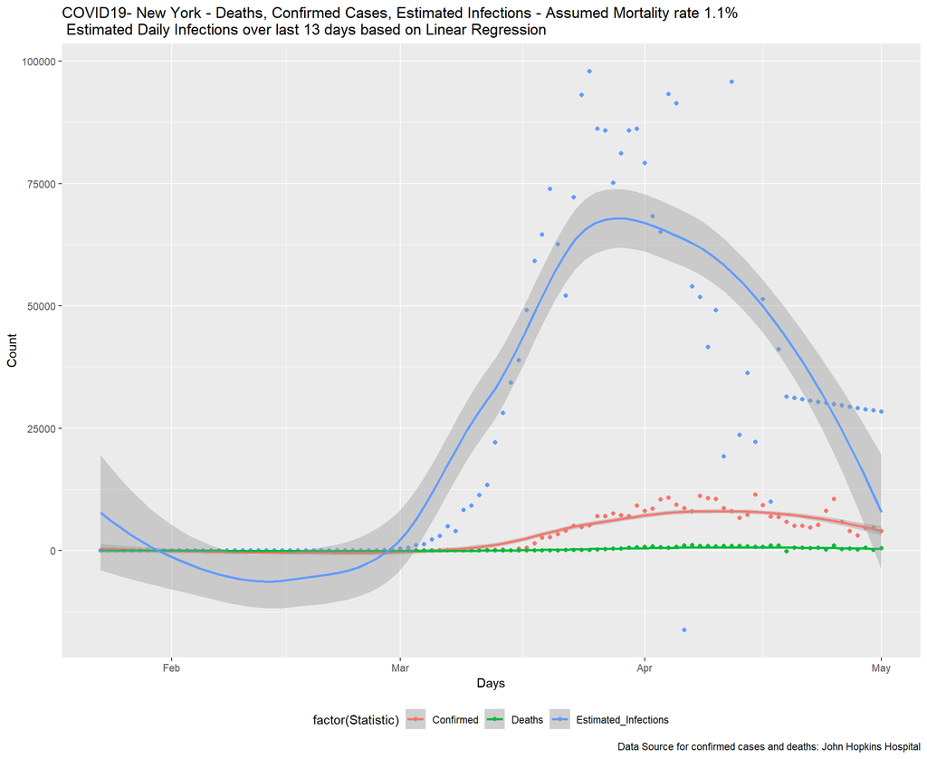

```r
Confirmed.US = read.csv("C:/Users/figue/OneDrive/Documents/GitHub/COVID-19/csse_covid_19_data/csse_covid_19_time_series/time_series_covid19_confirmed_US.csv",stringsAsFactors = FALSE)
Deaths.US = read.csv("C:/Users/figue/OneDrive/Documents/GitHub/COVID-19/csse_covid_19_data/csse_covid_19_time_series/time_series_covid19_deaths_US.csv",stringsAsFactors = FALSE)

#will have to summarize by Provice_State and Country_Region to use existing fuction
#Confirmed.US$Combined_Key

#Use the same format as global. With first 4 fields Province.State      Country.Region      Lat     Long and the rest dates

#will use dplyr to aggregate by State/Territory
library(dplyr)
Confirmed.US.States = Confirmed.US[c(7,8,12:dim(Confirmed.US)[2])] %>% group_by(Province_State,Country_Region) %>% summarise_at(colnames(Confirmed.US)[12:dim(Confirmed.US)[2]],sum)
#deaths US has an extra colymn for Population. It is not required at this point
Deaths.US.States = Deaths.US[c(7,8,13:dim(Deaths.US)[2])] %>% group_by(Province_State,Country_Region) %>% summarise_at(colnames(Deaths.US)[13:dim(Deaths.US)[2]],sum)




#now convert into dataframe that can be used. With the function created by country
#with first 4 columns named  Province.State Country.Region  Lat Long

# add two columns Lat and Long

Confirmed.US.States[c("Lat","Long")]=0
Deaths.US.States[c("Lat","Long")]=0

#change names of first 2 columns and reorder

colnames(Confirmed.US.States)[1:2] = c("Province.State","Country.Region")
colnames(Deaths.US.States)[1:2] = c("Province.State","Country.Region")

Ncol = dim(Confirmed.US.States)[2]
Confirmed.US.States= Confirmed.US.States[c(1,2,Ncol-1,Ncol,3:(Ncol-2))]

Ncol = dim(Deaths.US.States)[2]
Deaths.US.States= Deaths.US.States[c(1,2,Ncol-1,Ncol,3:(Ncol-2))]


Confirmed.US.States=as.data.frame(Confirmed.US.States)
Deaths.US.States=as.data.frame(Deaths.US.States)

#I will obtain differences with diff function


#diff(as.numeric(Confirmed[1,c(5:dim(Confirmed)[2])]))
#initialize
Confirmed_US_daily = diff(as.numeric(Confirmed.US.States[1,c(5:dim(Confirmed.US.States)[2])]))
for(i in 2:dim(Confirmed.US.States)[1]){
  Confirmed_US_daily=rbind(Confirmed_US_daily,diff(as.numeric(Confirmed.US.States[i,c(5:dim(Confirmed.US.States)[2])])))
}
#assign column names

colnames(Confirmed_US_daily) = colnames(Confirmed.US.States[,(6:dim(Confirmed.US.States)[2])])
#column bind

Confirmed_US_daily = cbind(Confirmed.US.States[,c(1:4)],Confirmed_US_daily)

#do the same for Deaths and Recovered


#diff(as.numeric(Deaths[1,c(5:dim(Deaths)[2])]))
#initialize
Deaths_US_daily = diff(as.numeric(Deaths.US.States[1,c(5:dim(Deaths.US.States)[2])]))
for(i in 2:dim(Deaths.US.States)[1]){
  Deaths_US_daily=rbind(Deaths_US_daily,diff(as.numeric(Deaths.US.States[i,c(5:dim(Deaths.US.States)[2])])))
}
#assign column names

colnames(Deaths_US_daily) = colnames(Deaths.US.States[,(6:dim(Deaths.US.States)[2])])
#column bind

Deaths_US_daily = cbind(Deaths.US.States[,c(1:4)],Deaths_US_daily)



Country.Long = Estimated.Daily.Infections.US(Confirmed_US_daily ,Deaths_US_daily,"US","New York",13,0.011)

ggplot(Country.Long, aes(x= Date, y= Count, group=Statistic )) +   geom_point(aes(color = factor(Statistic))) + geom_smooth(method = "loess", aes(color = factor(Statistic))) + theme(legend.position="bottom") + labs(title="COVID19- New York - Deaths, Confirmed Cases, Estimated Infections - Assumed Mortality rate 1.1% \n Estimated Daily Infections over last 13 days based on Linear Regression", y="Count", x="Days", caption="Data Source for confirmed cases and deaths: John Hopkins Hospital")
```

Create charts for Washington, California, Texas, Michigan and Florida

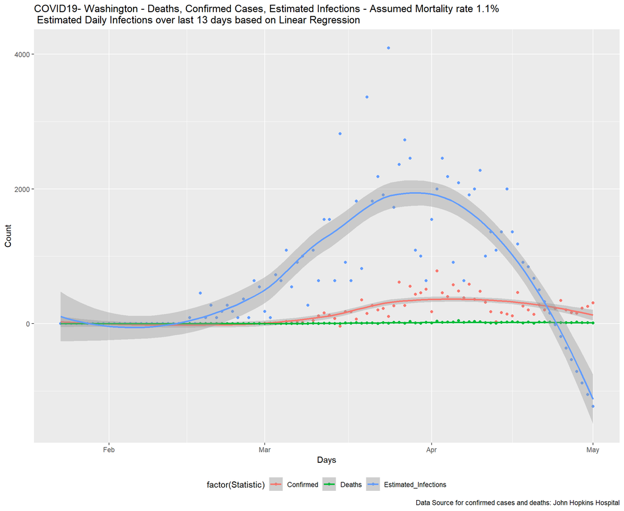

```r
Country.Long = Estimated.Daily.Infections.US(Confirmed_US_daily ,Deaths_US_daily,"US","Washington",13,0.011)

ggplot(Country.Long, aes(x= Date, y= Count, group=Statistic )) +   geom_point(aes(color = factor(Statistic))) + geom_smooth(method = "loess", aes(color = factor(Statistic))) + theme(legend.position="bottom") + labs(title="COVID19- Washington - Deaths, Confirmed Cases, Estimated Infections - Assumed Mortality rate 1.1% \n Estimated Daily Infections over last 13 days based on Linear Regression", y="Count", x="Days", caption="Data Source for confirmed cases and deaths: John Hopkins Hospital")
```

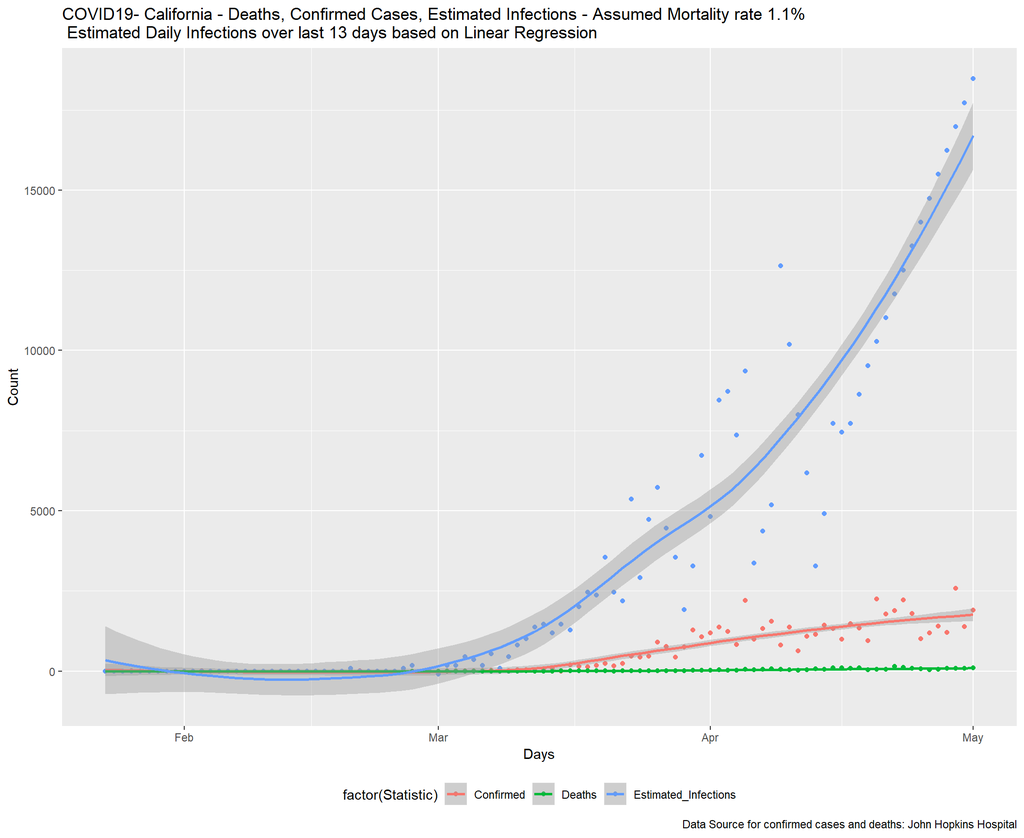

```r
Country.Long = Estimated.Daily.Infections.US(Confirmed_US_daily ,Deaths_US_daily,"US","California",13,0.011)

ggplot(Country.Long, aes(x= Date, y= Count, group=Statistic )) +   geom_point(aes(color = factor(Statistic))) + geom_smooth(method = "loess", aes(color = factor(Statistic))) + theme(legend.position="bottom") + labs(title="COVID19- California - Deaths, Confirmed Cases, Estimated Infections - Assumed Mortality rate 1.1% \n Estimated Daily Infections over last 13 days based on Linear Regression", y="Count", x="Days", caption="Data Source for confirmed cases and deaths: John Hopkins Hospital")
```

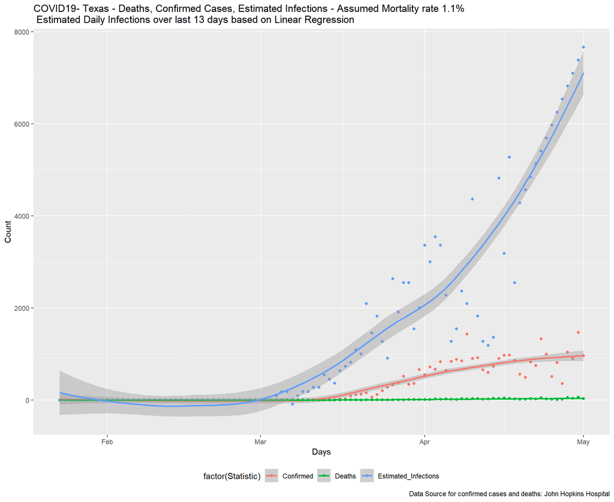

```r
Country.Long = Estimated.Daily.Infections.US(Confirmed_US_daily ,Deaths_US_daily,"US","Texas",13,0.011)

ggplot(Country.Long, aes(x= Date, y= Count, group=Statistic )) +   geom_point(aes(color = factor(Statistic))) + geom_smooth(method = "loess", aes(color = factor(Statistic))) + theme(legend.position="bottom") + labs(title="COVID19- Texas - Deaths, Confirmed Cases, Estimated Infections - Assumed Mortality rate 1.1% \n Estimated Daily Infections over last 13 days based on Linear Regression", y="Count", x="Days", caption="Data Source for confirmed cases and deaths: John Hopkins Hospital")
```

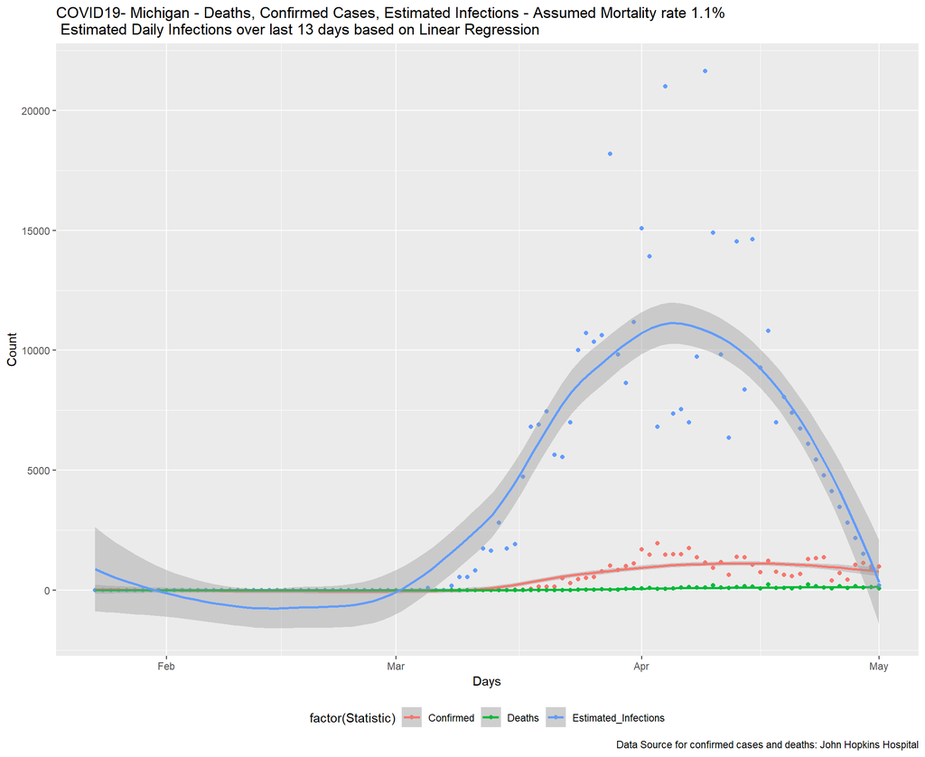

```r
Country.Long = Estimated.Daily.Infections.US(Confirmed_US_daily ,Deaths_US_daily,"US","Michigan",13,0.011)

ggplot(Country.Long, aes(x= Date, y= Count, group=Statistic )) +   geom_point(aes(color = factor(Statistic))) + geom_smooth(method = "loess", aes(color = factor(Statistic))) + theme(legend.position="bottom") + labs(title="COVID19- Michigan - Deaths, Confirmed Cases, Estimated Infections - Assumed Mortality rate 1.1% \n Estimated Daily Infections over last 13 days based on Linear Regression", y="Count", x="Days", caption="Data Source for confirmed cases and deaths: John Hopkins Hospital")
```

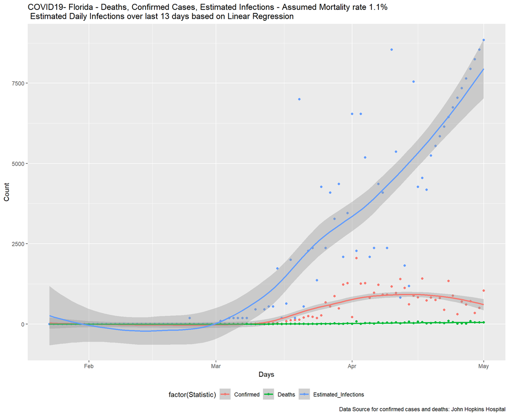

```r
Country.Long = Estimated.Daily.Infections.US(Confirmed_US_daily ,Deaths_US_daily,"US","Florida",13,0.011)

ggplot(Country.Long, aes(x= Date, y= Count, group=Statistic )) +   geom_point(aes(color = factor(Statistic))) + geom_smooth(method = "loess", aes(color = factor(Statistic))) + theme(legend.position="bottom") + labs(title="COVID19- Florida - Deaths, Confirmed Cases, Estimated Infections - Assumed Mortality rate 1.1% \n Estimated Daily Infections over last 13 days based on Linear Regression", y="Count", x="Days", caption="Data Source for confirmed cases and deaths: John Hopkins Hospital")
```

After reviewing the number of deaths for each of the previous states , it looks like with data as of May 1st the virus spread is slowing down in New York , washington and Michingan but not in other States. Having said this, the data is noisy so it might not be an accurate picture.

We should look at number of deaths by County in the US and calculate the % of all deaths. We should look into the distribution of the deaths by age group

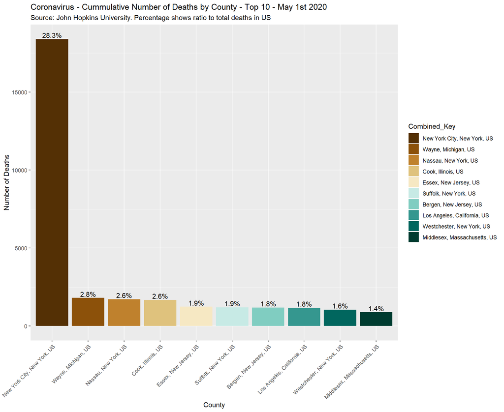

```r
# Get counts of total deaths for latest date
Deaths.US.Recent = Deaths.US[,c(1:12,dim(Deaths.US)[2])]
#order decreasing by County

Deaths.US.Recent=Deaths.US.Recent[order(Deaths.US.Recent[,13],decreasing=TRUE),]

Total.D = sum(Deaths.US.Recent[,13])
Total.P = sum(Deaths.US.Recent[,12])

Deaths.US.Recent$Perc_all_US = Deaths.US.Recent[,13]/Total.D
#cummulative percentage
Deaths.US.Recent$Cummu_Perc = cumsum(Deaths.US.Recent$Perc_all_US)

#Deaths in 100 out of 3,200+ Trerritories and counties make up 80%. 8 Make up 50%. 20 make more than 63%

# Show top 10 Locations with % of all US Deaths

#have to reorder labels
Top_10 = Deaths.US.Recent[1:10,]
#reorder. Changed combined Key to factory
Top_10$Combined_Key = as.factor(Top_10$Combined_Key)
#reorder factor according to ort of dataframe
Top_10$Combined_Key = factor(Top_10$Combined_Key, levels = Top_10$Combined_Key)

Top_10$Percent = paste(round(Top_10$Perc_all_US,3)*100,"%",sep="")

ggplot(Top_10, aes(x=Combined_Key, y=X5.1.20, fill = Combined_Key))+geom_bar(stat="identity") + labs(subtitle="Source: John Hopkins University. Percentage shows ratio to total deaths in US",
         title= "Coronavirus - Cummulative Number of Deaths by County - Top 10 - May 1st 2020") + theme(axis.text.x = element_text(angle = 45, hjust = 1)) + scale_fill_brewer(palette = "BrBG") + xlab("County") + ylab("Number of Deaths") + geom_text(aes(label=Percent), position=position_dodge(width=0.9), vjust=-0.25)
```

As of May 1st, 28% of all deaths associated to COVID 19 in the US were reported in New York City.

Distribution of deaths by Age Group according to CDC as of May 1st (last week of information was April 25th).The information comes from this web page:

https://www.cdc.gov/nchs/nvss/vsrr/COVID19/index.htm

Comparison to all deaths and deaths by flu.

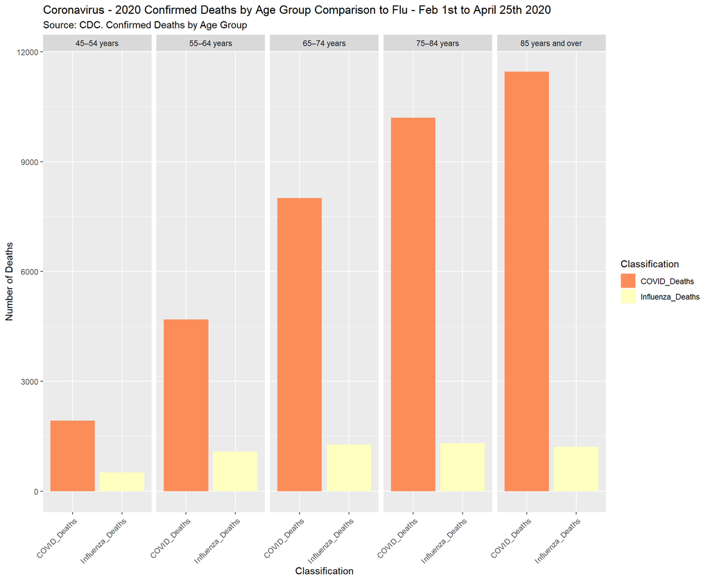

```r
CDC_Age = read.csv("C:/Users/figue/Documents/Coronavirus/CDC_Deaths_by_Age_May_1st.csv", stringsAsFactors = FALSE)
#comparison between Influenza Deaths and Coronavirus deaths by Age group
#Divide in 2 facegrid charts 45 and up   and under 45

CDC_Age_45up = CDC_Age[8:12,c("Indicator","All.COVID.19.Deaths..U07.1.","All.Influenza.Deaths..J09.J11.")]

colnames(CDC_Age_45up) = c("Age_group","COVID_Deaths","Influenza_Deaths")
CDC_Age_45up.Long = melt(CDC_Age_45up[c("Age_group","COVID_Deaths","Influenza_Deaths")],id="Age_group")

#rename columns
colnames(CDC_Age_45up.Long) = c("Age_Group","Classification","Deaths")
CDC_Age_45up.Long$Deaths = as.numeric(CDC_Age_45up.Long$Deaths)

ggplot(CDC_Age_45up.Long, aes(x=Classification, y=Deaths, group=Age_Group, fill = Classification))+geom_bar(stat="identity") + labs(subtitle="Source: CDC. Confirmed Deaths by Age Group",
         title= "Coronavirus - 2020 Confirmed Deaths by Age Group Comparison to Flu - Feb 1st to April 25th 2020") + scale_fill_brewer(palette = "Spectral") + xlab("Classification") + ylab("Number of Deaths")+ theme(axis.text.x = element_text(angle = 45, hjust = 1))  + facet_grid(. ~ Age_Group)
```

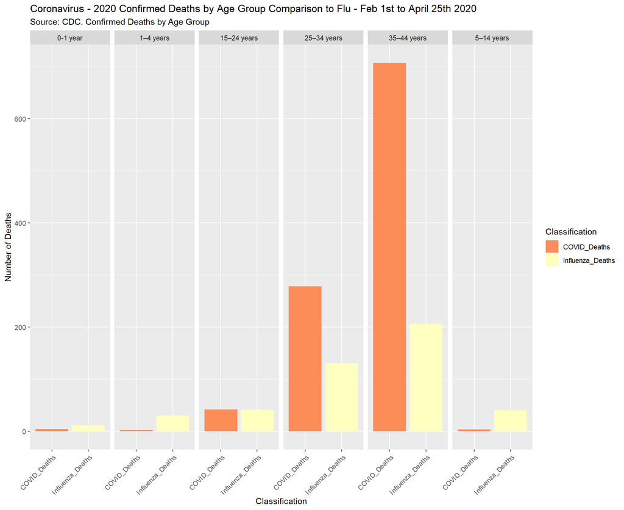

```r
#Do the same for Under 45

CDC_Age_45under = CDC_Age[2:7,c("Indicator","All.COVID.19.Deaths..U07.1.","All.Influenza.Deaths..J09.J11.")]

colnames(CDC_Age_45under) = c("Age_group","COVID_Deaths","Influenza_Deaths")
CDC_Age_45under.Long = melt(CDC_Age_45under[c("Age_group","COVID_Deaths","Influenza_Deaths")],id="Age_group")

#rename columns
colnames(CDC_Age_45under.Long) = c("Age_Group","Classification","Deaths")
CDC_Age_45under.Long$Deaths = as.numeric(CDC_Age_45under.Long$Deaths)

#replace Under 1 year with 0-1 year and other values. Html knitr is not working with factors
CDC_Age_45under.Long$Age_Group = ifelse(CDC_Age_45under.Long$Age_Group=="Under 1 year","0-1 year",CDC_Age_45under.Long$Age_Group)
CDC_Age_45under.Long$Age_Group = ifelse(CDC_Age_45under.Long$Age_Group=="1-4 years","01-4 years",CDC_Age_45under.Long$Age_Group)
CDC_Age_45under.Long$Age_Group = ifelse(CDC_Age_45under.Long$Age_Group=="5-14 years","05-14 years",CDC_Age_45under.Long$Age_Group)

#Have to reorder factors for Age group
#CDC_Age_45under.Long$Age_Group = as.factor(CDC_Age_45under.Long$Age_Group)


#CDC_Age_45under.Long$Age_Group = factor(CDC_Age_45under.Long$Age_Group , levels =c("0-1 year","1-4 years","5-14 years","15-24 years","25-34 years","35-44 years"))

ggplot(CDC_Age_45under.Long, aes(x=Classification, y=Deaths, group=Age_Group, fill = Classification))+geom_bar(stat="identity") + labs(subtitle="Source: CDC. Confirmed Deaths by Age Group",
         title= "Coronavirus - 2020 Confirmed Deaths by Age Group Comparison to Flu - Feb 1st to April 25th 2020") + scale_fill_brewer(palette = "Spectral") + xlab("Classification") + ylab("Number of Deaths")+ theme(axis.text.x = element_text(angle = 45, hjust = 1))  + facet_grid(. ~ Age_Group)
```

Now Calculate the mortality rate by Age Group based on Information from New York State and estimated number of Infections. https://www.census.gov/quickfacts/fact/table/NY/PST045219 Persons under 5 years, percent 5.8%

Persons under 18 years, percent 20.8%

Persons 65 years and over, percent 16.4%

This can be used to calculate the mortality rate by age group.

About 1.9 million were Infected in NY State (around 4/10). Based on John Hopkins University Information and a Mortality rate of about 1.1% overall (with a lag of 13 days). This is in line with estimated reported by the Wall Street Journal stating that more than 2 million people had been infected by COVID 19 as of April 23rd - this was based on an anti-bodies test.

~80% of the deaths are for people over 65 years old but they make up only 16.4% of the population in New York. Ratio of 4.87 deaths for people over 65 to people under 65 when infected

Number of deaths 20,973 as of 4/23, Of those 80% (16778) were people over 65. Estimated number of people infected in that age group were 311,600 around 4/10. So an estimated mortality rate for this age group is 5.3%.

For people under 65 (1,588,400) the mortality rate is about 0.26% based on an estimated number of deaths of 4,195. With most of the deaths falling in the group between 45 and 64 years old.

To be more accurate 20.8% of all population is under 18 years old and the number of deaths under this category is neglible. The total number of deaths will stay about the same around 4,195 but the poulation between 18 and 65 corresponds to 62.8% which would be about 1,193,200 of all infections. So the mortality rate in the group between 18 and 64 years old is 0.35% ; under 18 (even under 25) the mortality rate is very close to zero (probably lower mortality rate than Infuenza)

Have to calculate total percentage of deaths by Age group

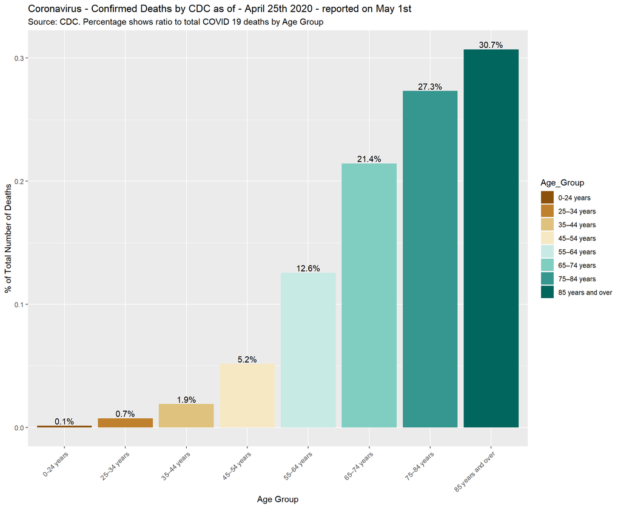

```r
CDC_Age_Perc = CDC_Age[2:12,c("Indicator", "Perc_Covid_Deaths" )]

CDC_Age_Perc1_24 = data.frame(Indicator="0-24 years",Perc_Covid_Deaths=sum(CDC_Age_Perc$Perc_Covid_Deaths[1:4]))

CDC_Age_Perc= rbind(CDC_Age_Perc, CDC_Age_Perc1_24)
#remove first 4 rows

CDC_Age_Perc = CDC_Age_Perc[5:12,]
#change column names

colnames(CDC_Age_Perc) = c("Age_Group","Perc_of_COVID19_Deaths")
#order

CDC_Age_Perc=CDC_Age_Perc[order(CDC_Age_Perc$Age_Group),]


CDC_Age_Perc$Percent = paste(round(CDC_Age_Perc$Perc_of_COVID19_Deaths,3)*100,"%",sep="")

ggplot(CDC_Age_Perc, aes(x=Age_Group, y=Perc_of_COVID19_Deaths, fill = Age_Group))+geom_bar(stat="identity") + labs(subtitle="Source: CDC. Percentage shows ratio to total COVID 19 deaths by Age Group",
         title= "Coronavirus - Confirmed Deaths by CDC as of - April 25th 2020 - reported on May 1st") + theme(axis.text.x = element_text(angle = 45, hjust = 1)) + scale_fill_brewer(palette = "BrBG") + xlab("Age Group") + ylab("% of Total Number of Deaths") + geom_text(aes(label=Percent), position=position_dodge(width=0.9), vjust=-0.25)
```

It is clear that based on previous analysis that focusing on protecting elderly population in New York City and other major metropolitan areas with high population density could reduce the number of Deaths by 40% or more going forward.